# Moose abundance

[NO_MOAB_001]

Author

Affiliation

Aud H. Halbritter

University of Bergen

Published

May 15, 2026

> **Recommended citation**: Halbritter, A. H. 2026. Moose abundance [Elgbestand] (ID(s): NO_MOAB_001) v. 1.0.0. ecRxiv: https://github.com/NINAnor/ecRxiv/tree/main/indicators/NO_MOAB_001

**TipMetadata**

Table 1: Indicator metadata

| Variable | Value |
| --- | --- |
| Indicator ID | NO_MOAB_001 |
| Indicator Name | Moose abundance [Elgbestand] |
| Country | Norway |
| Continent | Europe |
| Ecosystem Condition Typology Class | B3 Functional state characteristics |
| Realm | Terrestrial (T) |
| Biome | T2 Temperate-boreal forests and woodlands biome |
| Ecosystem | T2.1 Boreal/montane forests |
| Year added | 2026 |
| Last update | 2026 |
| Version | 1.0.0 |
| Version comment | First version on ecRxiv; indicator described in the Norwegian Nature Index |
| Normalised | TRUE |
| Spatial aggregation pathway | Aggregate (county level) - [Scale - Truncate] - Aggregate (national level) |

**TipLog**

- May 15, 2026 - Initial draft for ecRxiv

## 2. About the underlying data

The moose abundnace data comes from the national cervid monitoring programme and Hjorteviltregisteret (Landbruksdirektoratet and Norwegian Institute for Nature Research 2026; Landbruksdirektoratet 2026).

### 2.1 Spatial and temporal resolution and extent

Indicator values are available for the assessment years in Naturindeksen: 1990, 2000, 2010, 2014, 2019, and 2024.

To produce indicator estimates for these years, input is typically combined over a short window (typically two to three years), as specified in the Naturindeks indicator protocol.

Spatially, data and indicator values are handled at county (*fylke*) scale as IC units in Naturindeksen, then aggregated to five geographic regions and national level for reporting.

### 2.2 Sampling design

The national monitoring programme for cervids collects most material from harvested animals during hunting seasons (Landbruksdirektoratet and Norwegian Institute for Nature Research 2026). For moose, samples can include lower jaw and slaughter weight, and reproductive organs (egg stalks) from females (Landbruksdirektoratet and Norwegian Institute for Nature Research 2026). Further methodological detail for how county abundance enters Naturindeks is given on [Naturindeksen – elg](https://naturindeks.no/Indicators/elg).

### 2.3 Original units

The moose abundance is expressed as number of individuals per km².

### 2.4 Instructions for citing, using and accessing data

Monitoring programme: (Landbruksdirektoratet and Norwegian Institute for Nature Research 2026) and [Hjorteviltregisteret](https://www.hjorteviltregisteret.no) (Landbruksdirektoratet 2026).

Methodological documentation: [Naturindeksen – elg](https://naturindeks.no/Indicators/elg).

## 3. Indicator properties

### 3.1 Ecosystem Condition Typology Class (ECT)

B3 Functional state characteristics.

### 3.2 Ecosystem condition characteristic

### 3.3 Collinearities with other indicators

The indicator may covary with other cervid abundance indicators (red deer, roe deer) and with other species indicators that share similar habitats or data sources.

### 3.4 Impact factors

### 3.5 Spatial aggregation

Following the metadata pathway Aggregate (population model, county level) – [Scale – Truncate] – Aggregate (national level): population estimates or indices are available per county (IC unit in Naturindeksen). Each county value is normalised with a unimodal scaling function (optimum at *X<sub>100</sub>*; lower and upper reference values at *X<sub>0</sub>*; see Section 4.2). Regional (east, south, west, central, north) and national indicator values are then obtained as area-weighted combinations of the scaled county values.

## 4. Reference condition and levels

### 4.2 Reference levels

For this indicator, normalisation uses a unimodal scaling function. Optimum abundance corresponds to *X<sub>100</sub>*. The lower and upper reference values on the variable scale are both set at *X<sub>0</sub>*, so that densities both below and above the optimum are scaled towards worst condition.

#### 4.2.1 Spatial resolution and validity

Reference levels and indicator values apply at county (*fylke*) scale (IC units). Aggregated results for the five Naturindeks geographic regions and for Norway are summaries of those units with area weights. Normalisation should be done at county scale before regional or national aggregation.

## 5. Uncertainties

### 5.1 General uncertainties

Reference levels are held fixed in this workflow (their own uncertainties are not propagated). Regional and national values are area-weighted summaries of counties, so they inherit both model uncertainty at county scale and any mismatch between county boundaries and ecological variation within regions.

### 5.2 Reported uncertainties

The intervals in Table 2 and Figure 2 are **inferential**: they describe uncertainty around the estimated area-weighted mean indicator for each reporting unit (a geographic region or Norway as a whole), given the statistical models used for county-level abundance in Naturindeksen.

## 6. References

Landbruksdirektoratet. 2026. “Hjorteviltregisteret.” https://www.hjorteviltregisteret.no.

Landbruksdirektoratet, and Norwegian Institute for Nature Research. 2026. “Nasjonalt Overvåkingsprogram for Hjortevilt.” https://hjortevilt.no/forskning-og-viltovervaking/nasjonalt-bestandsovervakningsprogram-for-hjortevilt-bop.

Norwegian Institute for Nature Research, and partners. 2025. “Norwegian Nature Index (Naturindeks).” https://www.naturindeks.no.

## 7. Import and prepare datasets

Run the download chunk once to refresh the local export. This project’s renv environment installs `NIcalc` from GitHub `ChloeRN/NIcalc`, branch `include_ReadOnly_access` (see `renv.lock` and `install_deps.R`); that build defaults to the Naturindeks read-only API user, so you do not need `username` / `password` arguments here. When [NINAnor/NIcalc PR #59](https://github.com/NINAnor/NIcalc/pull/59) is merged into `NINAnor/NIcalc`, you can switch the renv install back to the main repo and update the lockfile. We save the RDS export under `data/` so that we do not need to download the data every time we run the analysis.

**Download moose data from Naturindeks API**

```r
moabImport <- NIcalc::importDatasetApi(
  eco = NULL,
  indic = c("Elg"),
  year = c("1990", "2000", "2010", "2014", "2019", "2024")
)

saveRDS(moabImport, here::here("data/moabImport.rds"))
```

## 9. Analyses

This section uses the following workflow: we take variable values and reference levels from the Naturindeks import, normalise at county scale, then propagate uncertainty and aggregate spatially with area weights. At regional and national scale, uncertainties are inferential: each replicate is an area-weighted mean based on one draw per county (then per region), not a random draw from a pooled mixture of counties. We use unimodal scaling and forest area (`Skog`) as weights.

County-level abundance in the database is stored as a predictive distribution (parameters or custom distributions), not only as a point estimate. Reference optimum density per county comes from the reference slice of the same download (`expectedValue` for the reference year). We ignore uncertainty in reference levels.

### Assemble import and indicator object

`assembleNiObject()` reshapes `moabImport` so that indicator observations are in one list element per assessment year, and so that municipality-level `BSunits` (with forest area and NI region code `part`) are aligned with the thematic index structure used in Naturindeks.

**Assemble moose NI object (thematic, predefined regions)**

```r
moabAssemble <- NIcalc::assembleNiObject(
  inputData = moabImport,
  predefNIunits = c(allArea = T, parts = T, counties = F),
  indexType = "thematic"
)
```

```
Check input data .....
```

```
Elicitate incomplete reference values and indicator observations .....
```

```
Assemble dataset .....
```

### Reference levels (X<sub>100</sub>)

Before scaling, we need the county-specific optimum on the variable scale (moose density, ind. km⁻² below the tree line). These are read from `referenceValues` in the RDS export (rows with `yearId == 0` or reference year name), one `x100` per IC unit (county).

**County reference optimum (X100) from downloaded Naturindeks data**

```r
x100 <- moabImport$referenceValues$referenceValues |>
  dplyr::filter(.data$yearId == 0L | grepl("Referanse", .data$yearName, fixed = FALSE)) |>
  dplyr::distinct(ICunitId, ICunitName, x100 = expectedValue)
x100 |>
  gt::gt()
```

| ICunitId | ICunitName | x100 |
| --- | --- | --- |
| 3613 | Østfold | 0.5 |
| 3614 | Akershus | 0.5 |
| 3615 | Hedmark | 0.4 |
| 3616 | Oppland | 0.4 |
| 3617 | Buskerud | 0.4 |
| 3618 | Vestfold | 0.5 |
| 3619 | Telemark | 0.3 |
| 3620 | Aust-Agder | 0.3 |
| 3621 | Vest-Agder | 0.3 |
| 3622 | Rogaland | 0.2 |
| 3623 | Hordaland | 0.2 |
| 3624 | Sogn og Fjordane | 0.2 |
| 3625 | Møre og Romsdal | 0.2 |
| 3626 | Sør-Trøndelag | 0.4 |
| 3627 | Nord-Trøndelag | 0.4 |
| 3628 | Nordland | 0.3 |
| 3629 | Troms | 0.3 |
| 3630 | Finnmark | 0.1 |

### Resample non-scaled county-scale variables

For each assessment year, Naturindeks stores county values as a parameterised distribution (or a custom distribution). We draw `nsim = 1000` random values per county with `NIcalc::sampleObsMat()`. Rows with a standard distribution family use observation type `tradObs`; rows with only a custom distribution use `customObs`.

Assessment years are the following: 1990, 2000, 2010, 2014, 2019, 2024. The result `dat` is a long table of simulated variable values (`value`) by `ICunitId` and `year` (not yet on the 0–1 indicator scale).

**Observation types for sampleObsMat**

```r
myYears <- as.character(c(1990, 2000, 2010, 2014, 2019, 2024))
obstype <- vector("list", length(myYears))
for (i in seq_along(myYears)) {
  obs <- moabAssemble$indicatorValues[[i]]$distributionFamilyName
  obs[!is.na(obs)] <- "tradObs"
  obs[is.na(obs)] <- "customObs"
  obstype[[i]] <- obs
}
```

**Resample county-scale variables (non-scaled)**

```r
dat <- tibble(ICunitId = NULL, value = NULL, year = NULL)

for (i in seq_along(myYears)) {
  myMat <- NIcalc::sampleObsMat(
    ICunitId = moabAssemble$indicatorValues[[i]]$ICunitId,
    value = moabAssemble$indicatorValues[[i]]$expectedValue,
    distrib = moabAssemble$indicatorValues[[i]]$distributionFamilyName,
    mu = moabAssemble$indicatorValues[[i]]$distParameter1,
    sig = moabAssemble$indicatorValues[[i]]$distParameter2,
    customDistribution = moabAssemble$indicatorValues[[i]]$customDistribution,
    obsType = obstype[[i]],
    nsim = 1000
  )
  ICunitIds <- row.names(myMat)
  colnames(myMat) <- paste0("s", seq_len(ncol(myMat)))
  myMat <- myMat |>
    as_tibble() |>
    add_column(ICunitId = ICunitIds, .before = 1) |>
    pivot_longer(cols = -any_of("ICunitId"), names_to = "sim_col", values_to = "value") |>
    mutate(
      sim_id = readr::parse_number(.data$sim_col),
      year = myYears[i]
    ) |>
    select(ICunitId, sim_id, value, year)

  dat <- dat |>
    bind_rows(myMat)
}
head(dat) |>
  gt::gt()
```

| ICunitId | sim_id | value | year |
| --- | --- | --- | --- |
| 3613 | 1 | 0.5638799 | 1990 |
| 3613 | 2 | 0.6173770 | 1990 |
| 3613 | 3 | 0.7865684 | 1990 |
| 3613 | 4 | 0.5446145 | 1990 |
| 3613 | 5 | 0.4133937 | 1990 |
| 3613 | 6 | 0.7163069 | 1990 |

### Scaling to indicator values (unimodal)

Normalisation is done at county scale before any regional or national aggregation. Each draw is joined to its county `x100`, then mapped to `[0, 1]` with `ecTools::ec_normalise()` in two-sided mode: `x0 = 0` and `x100` = optimum from the download define the best condition; `x0h = 2 * x100` is a simple upper anchor for “too high” density (adjust if you adopt explicit upper limits from NI documentation). The `sigmoid` option applies a non-linear transform after the piecewise linear mapping, in line with unimodal indicators in Naturindeks (Norwegian Institute for Nature Research and partners 2025).

**Join X100 and unimodal scaling to indicator scale**

```r
dat <- dat |>
  left_join(x100 |> mutate(ICunitId = as.character(ICunitId)), by = join_by(ICunitId))

ind <- ec_normalise(
  variable = dat$value,
  x0 = 0,
  x100 = dat$x100,
  x0h = 2 * dat$x100,
  fun = "sigmoid"
)

dat <- dat |> add_column(indicator = ind)
```

The scatter plot below (Figure 1) shows the mapping from variable to indicator for each county (one facet per `ICunitName`). The figure is saved when the document is rendered.

**Save normalisation diagnostic figure (English)**

```r
moose_plot <-ec_norm_plot(dat$value, dat$indicator) +
  facet_wrap(. ~ dat$ICunitName)
ggsave(filename = here::here("img/moab_norm_plot_eng.png"), plot = moose_plot, scale = 1.5)
```

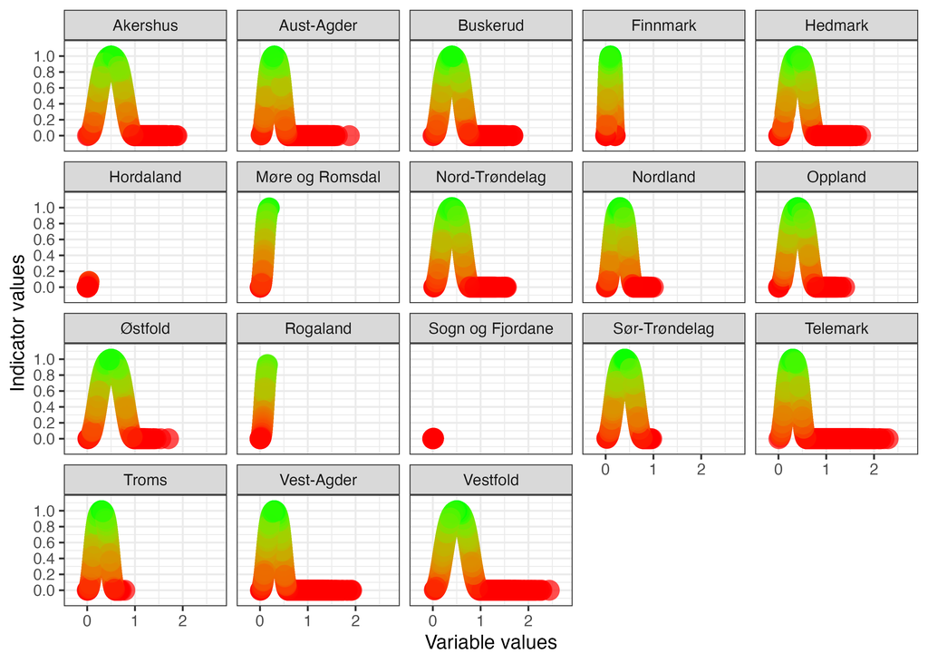

Figure 1: Unimodal normalisation of moose density to indicator values (one panel per county).

```r
knitr::include_graphics(here::here("img/moab_norm_plot_eng.png"))
```

### Aggregation weights (forest area by county)

Spatial aggregation uses area below the tree line recorded in Naturindeks (`Skog` on each municipality in `BSunits`). Municipalities are linked to counties via `ICunits`, then forest area is summed to county (`ICunitId`) and the NI region `part` (N, C, W, S, E) is kept for the next step. Each row in `dat` then carries `forest_area` and `part` for weighting.

**Forest area by county and NI region for aggregation weights**

```r
aux <- as_tibble(moabAssemble$BSunits) |>
  rename(BSunitId = id)

IC_BC_link <- moabImport$ICunits |>
  select(ICunitId = id, BSunitId)

aux <- aux |>
  left_join(IC_BC_link, by = join_by(BSunitId))

aux <- aux |>
  group_by(ICunitId) |>
  summarise(forest_area = sum(Skog), part = unique(part)) |>
  mutate(ICunitId = as.character(ICunitId))

dat <- dat |>
  left_join(aux, by = join_by(ICunitId))
```

### Aggregate to geographic regions (inferential uncertainty)

For each Monte Carlo replicate (b = 1, , 1000) and each region–year, we draw one posterior sample per county (from that county’s 1000 simulations in `dat`), then compute the forest-area-weighted mean across counties in the region. The resulting 1000 values describe uncertainty around the regional mean indicator.

**Bootstrap distribution of area-weighted regional means**

```r
regions <- c("N", "C", "W", "S", "E")
B <- 1000L

out <- tibble(id = seq_len(B))

for (i in regions) {
  for (n in myYears) {
    d_yr <- dat |>
      filter(.data$part == i, .data$year == n)

    counties <- sort(unique(d_yr$ICunitId))
    w <- aux |>
      filter(.data$ICunitId %in% counties) |>
      arrange(match(.data$ICunitId, counties))

    by_county <- split(d_yr$indicator, d_yr$ICunitId)[counties]

    col_vals <- vapply(
      seq_len(B),
      function(b) {
        draws <- vapply(by_county, sample, numeric(1), size = 1L)
        stats::weighted.mean(draws, w$forest_area)
      },
      numeric(1)
    )

    out <- out |>
      add_column(!!paste(i, n, sep = "_") := col_vals)
  }
}
head(out)
```

```
# A tibble: 6 × 31
     id N_1990 N_2000 N_2010 N_2014 N_2019 N_2024 C_1990 C_2000 C_2010 C_2014
  <int>  <dbl>  <dbl>  <dbl>  <dbl>  <dbl>  <dbl>  <dbl>  <dbl>  <dbl>  <dbl>
1     1  0.199  0.901  0.693  0.513  0.942  0.507  0.763  0.858  0.845  0.630
2     2  0.265  0.858  0.569  0.833  0.610  0.697  0.794  0.454  0.805  0.595
3     3  0.260  0.878  0.650  0.847  0.905  0.601  0.776  0.782  0.671  0.753
4     4  0.307  0.663  0.842  0.801  0.644  0.763  0.737  0.670  0.332  0.495
5     5  0.421  0.607  0.752  0.693  0.847  0.649  0.648  0.996  0.923  0.351
6     6  0.433  0.888  0.901  0.967  0.627  0.556  0.740  0.948  0.745  0.347
# ℹ 20 more variables: C_2019 <dbl>, C_2024 <dbl>, W_1990 <dbl>, W_2000 <dbl>,
#   W_2010 <dbl>, W_2014 <dbl>, W_2019 <dbl>, W_2024 <dbl>, S_1990 <dbl>,
#   S_2000 <dbl>, S_2010 <dbl>, S_2014 <dbl>, S_2019 <dbl>, S_2024 <dbl>,
#   E_1990 <dbl>, E_2000 <dbl>, E_2010 <dbl>, E_2014 <dbl>, E_2019 <dbl>,
#   E_2024 <dbl>
```

### Aggregate to national level (inferential uncertainty)

For each year and replicate (b), the national value is the forest-area-weighted mean of the five regional values from that same replicate (`aux2` gives total forest area per region). This propagates uncertainty to the national mean in the same way as at regional scale.

**Bootstrap distribution of area-weighted national means**

```r
aux2 <- aux |>
  group_by(part) |>
  summarise(forest_area = sum(.data$forest_area), .groups = "drop")

w_region <- aux2$forest_area[match(regions, aux2$part)]

out2 <- tibble(id = seq_len(B))

for (n in myYears) {
  nat_vals <- vapply(
    seq_len(B),
    function(b) {
      reg_draws <- vapply(
        regions,
        function(r) out[[paste(r, n, sep = "_")]][b],
        numeric(1)
      )
      stats::weighted.mean(reg_draws, w_region)
    },
    numeric(1)
  )

  out2 <- out2 |>
    add_column(!!paste("All", n, sep = "_") := nat_vals)
}

head(out2)
```

```
# A tibble: 6 × 7
     id All_1990 All_2000 All_2010 All_2014 All_2019 All_2024
  <int>    <dbl>    <dbl>    <dbl>    <dbl>    <dbl>    <dbl>
1     1    0.365    0.533    0.482    0.496    0.532    0.555
2     2    0.332    0.410    0.440    0.592    0.567    0.584
3     3    0.478    0.559    0.477    0.668    0.500    0.538
4     4    0.527    0.387    0.417    0.638    0.681    0.470
5     5    0.495    0.485    0.509    0.600    0.497    0.624
6     6    0.572    0.492    0.514    0.538    0.662    0.528
```

**Bootstrap distribution of area-weighted national means**

```r
out <- out |>
  bind_cols(out2 |> select(-id))
```

## 10. Results

```r
summary_out <- out |>
  pivot_longer(cols = !any_of("id")) |>
  separate_wider_delim(cols = name, delim = "_", names = c("part", "year")) |>
  group_by(part, year) |>
  summarise(
    median = round(median(value), 2),
    p_025 = round(quantile(value, probs = 0.0025), 2),
    p_25 = round(quantile(value, probs = 0.25), 2),
    p_75 = round(quantile(value, probs = 0.75), 2),
    p_975 = round(quantile(value, probs = 0.975), 2),
  ) |>
  add_column(
    ECT = "B3",
    Indicator = "Moose abundance",
    Ecosystem = "Boreal/montane forests",
    ID = "NO_MOAB_001"
  ) |>
  mutate(
    part = case_when(
      part == "All" ~ "Norway",
      part == "N" ~ "North",
      part == "C" ~ "Central",
      part == "W" ~ "West",
      part == "S" ~ "South",
      part == "E" ~ "East",
      TRUE ~ part
    )
  )
```

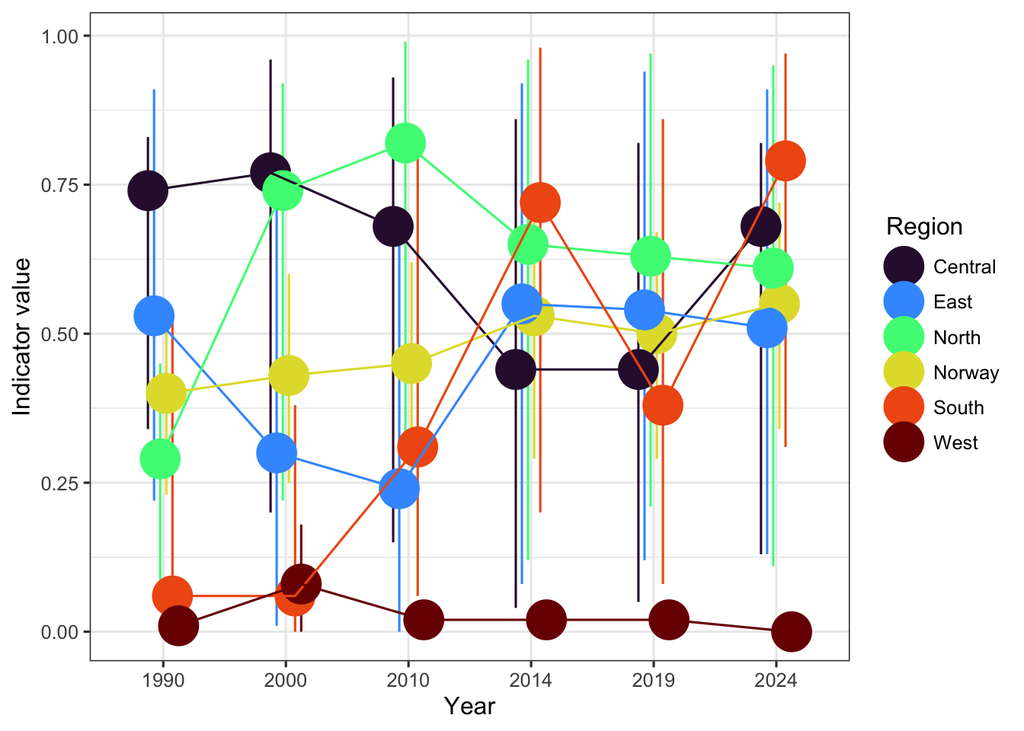

Figure 2: Indicator values for moose abundance by region and nationally, with uncertainty bands from the resampled distribution.

```r
summary_out |>
  ggplot(aes(x = year, y = median, colour = part, group = part)) +
  geom_pointrange(
    aes(ymin = p_025, ymax = p_975),
    size = 2,
    position = position_dodge(width = 0.3)
  ) +
  geom_line(position = position_dodge(width = 0.3)) +
  theme_bw(base_size = 12) +
  labs(y = "Indicator value", x = "Year") +
  scale_colour_viridis_d(option = "turbo", name = "Region")
```

```r
summary_out |>
  unite(col = "CI_95", c(p_025, p_975), sep = " - ") |>
  unite(col = "IQR", c(p_25, p_75), sep = " - ") |>
  select(
    ECT,
    Indicator,
    ID,
    "Accounting area" = part,
    Ecosystem,
    "Closing year" = year,
    "Indicator value" = median,
    "95% CI" = CI_95,
    "50% CI" = IQR
  ) |>
  kable()
```

Table 2: Indicator values and uncertainty estimates for moose abundance.

[output not shown]

## 11. Export file

**Export resampled indicator draws**

```r
write.csv(out, here::here("data/results_NO_MOAB_001_v1.0.0.csv"), row.names = FALSE)
```

Not relevant, as this is the work of a single author. I would, however, like to acknowledge the work of those that created the indicator on *Naturindeks* (Norwegian Institute for Nature Research and partners 2025).

**TipSession Info**